# Network and Routing

Antonio Paez

2023-06-15

In this document I collect and preprocess the network data for this research.

# Preliminaries

Load packages:

```r
# Allocate memory
options(java.parameters = "-Xmx20G")

library(disk.frame) # Larger-than-RAM Disk-Based Data Manipulation Framework
library(dplyr) # A Grammar of Data Manipulation
library(ggforce) # Accelerating 'ggplot2'
library(ggplot2) # Create Elegant Data Visualisations Using the Grammar of Graphics
library(h3) # R Bindings for H3
library(purrr) # Functional Programming Tools
library(r5r) # Rapid Realistic Routing with 'R5'
library(sf) # Simple Features for R
library(skimr) # Compact and Flexible Summaries of Data
library(units) # Measurement Units for R Vectors
library(vaccHamilton) # A Data Package to Estimate Accessibility of Vaccination Sites in Hamilton, ON
```

Load data objects from package {vaccHamilton}. Urban types is the way the City of Hamilton classifies different parts of the city as “Urban”, “Suburban”, and “Rural”. The second object (`data_da_2016`) includes the geometry of Dissemination Areas and some demographic data for 2016:

```r
data("urban_types")
data("data_da_2016")
```

Use only urban and suburban Hamilton:

```r
urban_hammer <- urban_types |>
  filter(Type != "Rural")
```

Find the DAs that are urban or suburban:

```r
urban_hammer_da <- data_da_2016 |>
  st_transform(crs = st_crs(urban_types)) |>
  st_intersection(urban_hammer)
```

Plot urban/suburban DAs:

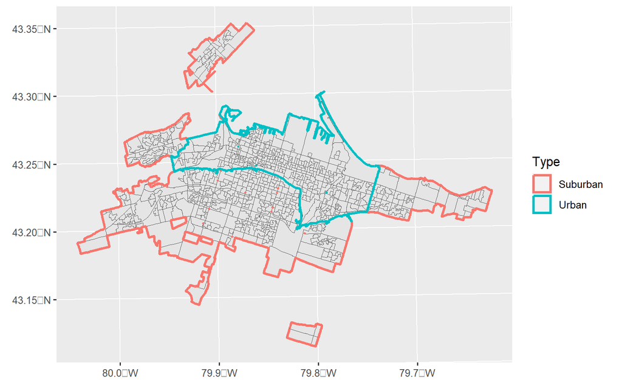

```r
ggplot() +
  geom_sf(data = urban_hammer_da) +
  geom_sf(data = urban_hammer,
          aes(color = Type),
          fill = NA,
          linewidth = 1)
```

Notice that some DAs appear twice after intersecting with urban fabric types:

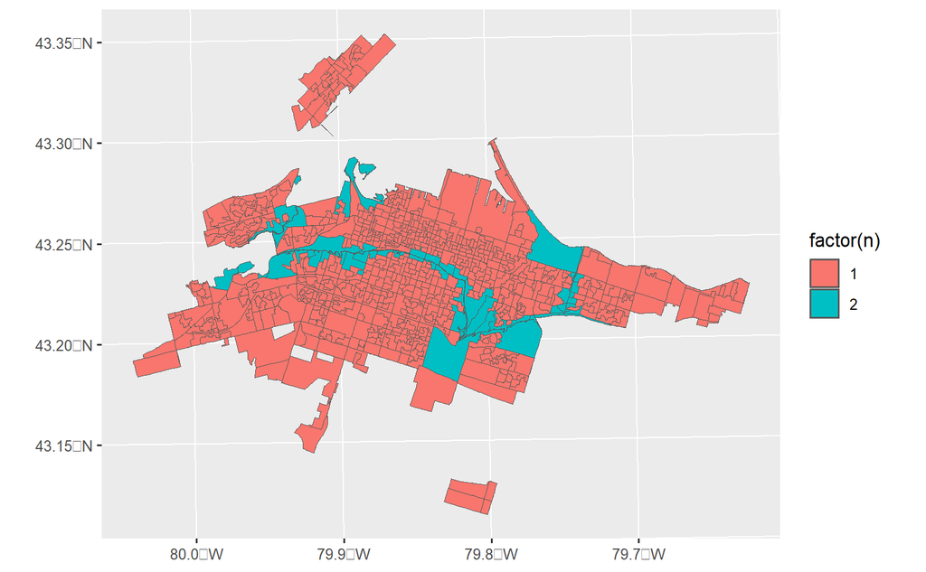

```r
urban_hammer_da |>
  left_join(
    urban_hammer_da |>
      st_drop_geometry() |>
      group_by(GeoUID) |>
      summarize(n = n()),
    by = "GeoUID") |>
  ggplot() +
  geom_sf(aes(fill = factor(n)))
```

Coordinates of centroids of the DAs that intersect urban/suburban types (in lat-long). These will be the origins of trips, that is, our proxies for “neighborhoods”:

```r
origins <- st_centroid(urban_hammer_da) |>
  st_transform(crs = st_crs(4326))
```

# Geohashes

The simplest way to proceed, other than trying to calculate the travel times to every single amenity (and considering that we will at some point simulate the locations of amenities) is to geohash the region of interest. That way, we can count the number of amenities for polygons with precalculated travel times.

```r
urban_hammer_h3 <- geo_to_h3(c(43.2501, -79.8496),
                             res = 4) |>
  k_ring(radius = 1)
```

Plot the geohash retrieved in this way:

```r
ggplot() +
  geom_sf(data = h3_to_geo_boundary_sf(urban_hammer_h3),
          aes(fill = h3_index)) +
  geom_sf(data = urban_types,
          fill = NA)
```

Keep only the h3 indices that overlap with Hamilton:

```r
urban_hammer_h3 = c("842b9b7ffffffff", "842b9b5ffffffff", "842ab4bffffffff")
```

Plot kept indices:

```r
ggplot() +
  geom_sf(data = h3_to_geo_boundary_sf(urban_hammer_h3),
          aes(fill = h3_index)) +
  geom_sf(data = urban_types,
          fill = NA)
```

Obtain children at a higher resolution:

```r
urban_hammer_h3 <- urban_hammer_h3 |>
  purrr::map(\(x) h3_to_children(x, res = 8)) |>
  unlist()
```

Plot current geohashes:

```r
ggplot() +
  geom_sf(data = h3_to_geo_boundary_sf(urban_hammer_h3)) +
  geom_sf(data = urban_types,
          fill = NA)
```

Choose only hexagons that touch urban/suburban Hamilton:

```r
urban_hammer_h3 <- h3_to_geo_boundary_sf(urban_hammer_h3) |>
  st_transform(crs = st_crs(urban_types)) |>
  st_intersection(urban_types |>
                    filter(Type != "Rural"))

urban_hammer_h3 <- urban_hammer_h3 |>
  pull(h3_index)
```

Plot:

```r
ggplot() +
  geom_sf(data = h3_to_geo_boundary_sf(urban_hammer_h3)) +
  geom_sf(data = urban_types,
          fill = NA)
```

Currently this is resolution 8:

```r
h3_get_resolution(urban_hammer_h3)
```

Obtain children at resolution 13 (average area is 43.87 $m^2$):

```r
urban_hammer_h3 <- urban_hammer_h3 |>
  purrr::map(\(x) h3_to_children(x, res = 13)) |>
  unlist()
```

```r
destinations_h3 <- h3_to_geo(urban_hammer_h3)
```

## Network routing

Download and import GTFS (Hamilton transit data)

```r
download.file(url = "https://transitfeeds.com/p/hamilton-street-railway/31/latest/download",
              destfile = file.path(r5_path,
                                   "HSR_transit.zip"),
              mode = "wb")
```

```r
download.file(url = "https://transitfeeds.com/p/burlington-transit/294/latest/download",
              destfile = file.path(r5_path,
                                   "Burlington_transit.zip"),
              mode = "wb")
```

Prepare Input Data for `r5r`. The origins are the coordinates of the DAs and the destinations the coordinates of the h3 geohashes:

```r
# save origins in format expected by R5R (id, lon, lat)
origins_i <- data.frame(ID = origins$GeoUID,
                        origins |>
                          st_transform(crs = 4326) |>
                          st_coordinates()) |>
  rename(lon = X, lat = Y, id = ID) |>
  dplyr::select(id, lon, lat)

# now vaccination sites
destinations_j <- data.frame(id = urban_hammer_h3,
                             lat = destinations_h3[,1],
                             lon = destinations_h3[,2])
```

Calculate OD Matrix for walking:

```r
# set up batching according to how many origin rows to process at one time
chunksize = 4000 # larger chunks for walking will give enough origins in each chunk to allow multiprocessing to spin up with R5R
num_chunks = ceiling(nrow(origins_i)/chunksize)

# create origin-destination pairs
origins_chunks <- as.disk.frame(origins_i,
                                outdir = "./df/origins_i",
                                nchunks = num_chunks,
                                overwrite = TRUE)

start.time <- Sys.time()
pb <- txtProgressBar(0, num_chunks, style = 3)

for (i in 1:num_chunks){
  origins_i_chunk <- get_chunk(origins_chunks, i)
  ttm_chunk <- travel_time_matrix(r5_hamilton_cma,
                                  origins = origins_i_chunk,
                                  destinations = destinations_j,
                                  mode = c("WALK"),
                                  departure_datetime = as.POSIXct(strptime("2021-04-05 08:00:00", "%Y-%m-%d %H:%M:%S", tz = "EST5EDT")),
                                  max_walk_time = 15, # minutes
                                  max_trip_duration = 15)

  # export output as disk.frame
  ifelse(i == 1, output_df <- as.disk.frame(ttm_chunk,
                                            nchunks = 1,
                                            outdir = "./df/output_ttm_walk",
                                            compress = 50,
                                            overwrite = TRUE),
         add_chunk(output_df, ttm_chunk, chunk_id = i))
  setTxtProgressBar(pb, i)
}
end.time <- Sys.time()
ttm_walk_time <- end.time - start.time
ttm_walk_time
```

Retrieve network as a simple features object:

```r
hamilton_net <- street_network_to_sf(r5_hamilton_cma)
```

Save network as sf:

```r
save(hamilton_net, file = "hamilton_net.rda", compress = "xz")
```

## Extract travel time matrix

Convert disk.frame to data frame:

```r
ttm_walk <- as.data.frame(ttm_walk.disk.frame) |>
  transmute(GeoUID = from_id, h3_index = to_id, travel_time = travel_time_p50)
```

## Retrieve h3 geometries of walksheds by origin

Retrieve the h3 areas as multipolygons:

```r
walksheds <- ttm_walk |>
  group_by(GeoUID) |>
  group_map(~ h3_set_to_multi_polygon(.x$h3_index),
            .keep = TRUE)
```

Obtain the GeoUIDs of the walksheds:

```r
walkshed_GeoUIDs <- ttm_walk |>
  group_by(GeoUID) |>
  summarize(GeoUID = first(GeoUID),
            .groups = "drop")
```

Convert walksheds with GeoUIDs of DAs to a data frame:

```r
walksheds <- data.frame(GeoUID = walkshed_GeoUIDs,
                         geometry = purrr::map_df(walksheds,
                            tibble::as_tibble)) |>
  st_as_sf(crs = 4326)
```

Verify the catchments:

```r
test_unit = sample.int(nrow(walksheds), 1)

ggplot() +
  geom_sf(data = data_da_2016 |>
            filter(GeoUID == walksheds$GeoUID[test_unit]),
          color = "black",
          fill= NA) +
  geom_sf(data = walksheds[test_unit,],
          color = "blue",
          fill = NA,
          linewidth = 1)
```

Join the urban type to DAs in the walksheds object:

```r
walksheds <- walksheds |>
  left_join(origins |>
              st_drop_geometry() |>
              transmute(GeoUID, Type = Type.1),
            by = "GeoUID")
```

Convert to factor:

```r
walksheds <- walksheds |>
  mutate(Type = factor(Type))
```

Summarize the walksheds:

```r
summary(walksheds)
```

The DAs and the catchments match. Now save the data objects:

```r
save(urban_hammer_da, file = "urban_hammer_da.rda", compress = "xz")
save(ttm_walk, file = "ttm_walk.rda", compress = "xz")
save(walksheds, file = "walksheds.rda", compress = "xz")
```

Calculate area of walksheds:

```r
walksheds <- walksheds |>
  mutate(area = st_area(geometry))
```

Summarize by urban type:

```r
walksheds |>
  st_drop_geometry() |>
  mutate(area = units::drop_units(area)) |>
  group_by(Type) |>
  skim()
```

```
── Data Summary ────────────────────────
                           Values
Name                       group_by(...)
Number of rows             889
Number of columns          3
_______________________
Column type frequency:
  character                1
  numeric                  1
________________________
Group variables            Type
```

|  | skim_variable | Type | n_missing | complete_rate | min | max | empty | n_unique | whitespace |
| --- | --- | --- | --- | --- | --- | --- | --- | --- | --- |
| 1 | GeoUID | Suburban | 0 | 1 | 8 | 8 | 0 | 515 | 0 |
| 2 | GeoUID | Urban | 0 | 1 | 8 | 8 | 0 | 374 | 0 |

|  | skim_variable | Type | n_missing | complete_rate | mean | sd | p0 | p25 | p50 | p75 | p100 | hist |
| --- | --- | --- | --- | --- | --- | --- | --- | --- | --- | --- | --- | --- |
| 1 | area | Suburban | 0 | 1 | 1090547 | 292535.1 | 185370.0 | 913444.2 | 1100484 | 1274716 | 2257396 | ▁▅▇▂▁ |
| 2 | area | Urban | 0 | 1 | 1314151 | 324350.1 | 142669.8 | 1095790.0 | 1372092 | 1569837 | 2257396 | ▁▂▆▇▁ |

```r
walksheds |>
  st_drop_geometry() |>
  mutate(area = log(units::drop_units(set_units(area, km2)))) |>
  lm(area ~ Type, data = _) |>
  summary()
```

```
Call:
lm(formula = area ~ Type, data = mutate(st_drop_geometry(walksheds),
    area = log(units::drop_units(set_units(area, km2)))))

Residuals:
     Min       1Q   Median       3Q      Max
-2.18015 -0.13699  0.06678  0.21101  0.77046

Coefficients:
            Estimate Std. Error t value Pr(>|t|)
(Intercept)  0.04375    0.01380   3.170  0.00157 **
TypeUrban    0.18918    0.02128   8.891  < 2e-16 ***
---
Signif. codes:  0 ‘***’ 0.001 ‘**’ 0.01 ‘*’ 0.05 ‘.’ 0.1 ‘ ’ 1

Residual standard error: 0.3132 on 887 degrees of freedom
Multiple R-squared:  0.08183,   Adjusted R-squared:  0.0808
F-statistic: 79.06 on 1 and 887 DF,  p-value: < 2.2e-16
```

[figure not shown]

```r
walksheds |>
  st_drop_geometry() |>
  mutate(area = units::drop_units(area)) |>
  filter(Type == "Urban", area >= 1372092 * 0.999 & area <= 1372092 * 1.001)
```

| GeoUID | Type | area |
| --- | --- | --- |
| 35250333 | Urban | 1372522 |
| 35250430 | Urban | 1371247 |
| 35250455 | Urban | 1371391 |
| 35250503 | Urban | 1371663 |

[output not shown]

[output cut: 6 more lines]

Compare the areas of walksheds using comparable areas:

```r
mock_areas <- data.frame(Type = c("Suburban",
                          "Urban"),
                 area = c(1100484,
                          1372092),
                 x0 = c(0,0),
                 y0 = c(0,0)) |>
  mutate(r = sqrt(area/pi))
```

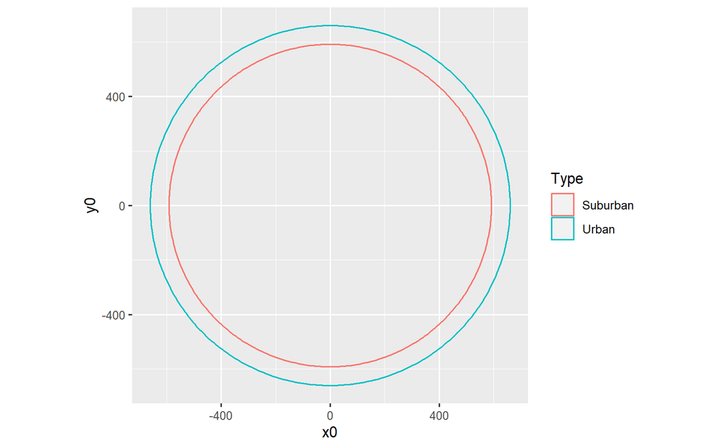

```r
ggplot() +
  geom_circle(data = mock_areas,
              aes(x0 = x0,
                  y0 = y0,
                  r = r,
                  color = Type))+
  coord_equal()
```